# The Role of Data Science in Pursuit of Long-Term Relationship Between Respondents and Researchers

Data Science for Social Good, Chicago 2017

## The urgent need for declarative data

## Declarative data are (and will) be needed !

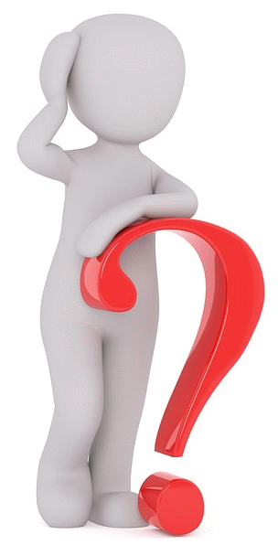

- In order **to solve many social problems** we often
  - need to conduct an **ad-hoc study** and
  - **gather new quantitative data**  
    from population of interest.
- **Existing data** can be not comprehensive enough  
  or not up-to-date.
- The solution is to **ask people relevant questions directly** and gather enough declarative data  
  of **acceptable quality**.

## Barriers in declarative data collection

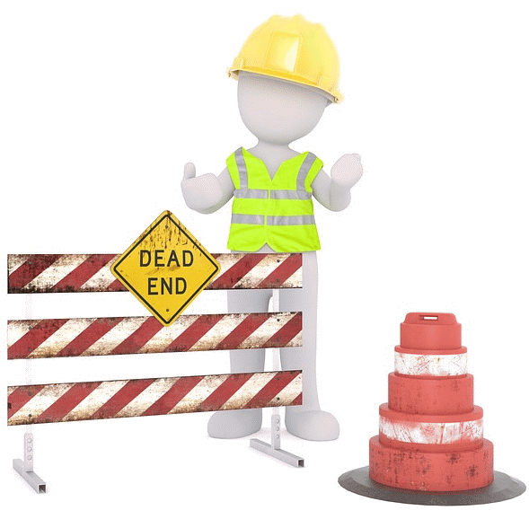

- We could conduct a survey using one of off-line or on-line research techniques…
- …but we will face **barriers** that can prevent even most important social research projects from being conducted, for example:
  - surveying people is **expensive**,
  - respondents are **hard to recruit**,
  - **response rates** are declining, and
  - **methodological concerns** are rising.
- The problems are growing even more, if we want to establish **long-term relationship** with respondents
  - i.e. to conduct **repeated measurements** within longitudinal panels (when we want to return with our questions to the same respondents at least once after some time).

## Why is it so difficult to establish long-term relationship between researchers and respondents?

## The heuristic of the traditional model of Respondent-Researcher Relationship

[figure not shown]

1. **Find potential respondents** within time window that is not necessarily convenient for them.
2. Convince them to **devote their time** to work through a questionnaire, which is often boring.
3. Convince them to share some **valuable**, also often quite **private** and **sensitive information** with someone who will benefit from their answers.
4. Do **not share** any **valuable information with them**.
5. Give the respondents **as little as possible in return** in order to be as much cost-effective as possible.
6. **Repeat** the whole process as **many times** and  
   for as **many respondents** as necessary.

## Consequence of the traditional model

Respondents **do not want** to be respondents anymore!

In the long run this model is clearly **not sustainable** but researchers **act like** the **general population** of respondents is **infinite** or it is an **easily renewable resource**.

This is not only **wrong** but also **harmful**!

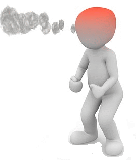

This situation can be seen as the classic "tragedy of the commons" describing a situation where a **shared resource is spoiled and depleted** by collective actions of all the actors driven by their individual self-interest **which is at odds** with the **long-term interests of the common good**.

## Old paradigm in on-line research techniques

On-line research techniques are **not natively on-line**.  
They simply **mimic off-line** techniques.

They are **mainly off-line questionnaires** converted into more or less advanced **HTML forms** with some additional functionalities (like randomization, skip logic, new question types) but they are still:

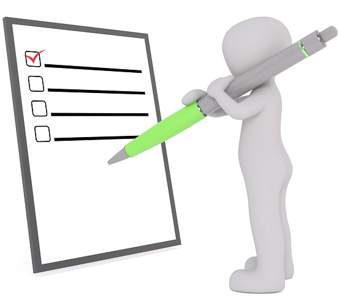

- **repetitive**—many questions from one survey is repeated in others;
- **time-consuming**—need a relatively long block of time to complete;
- **linear**—non-linear behavior is often forbidden;
- **based on non-equivalent information exchange**  
  —valuable information from respondent vs.  
  no valuable information from researcher.

## Towards new paradigm in declarative data collection

## Assumption of the new model of Respondent-Researcher Relationship

- The priority is to build **long-term relationship** with respondents.
- The process should be more similar to a **conversation** than an **interrogation**.
- The **new research tool** for collecting declarative data should be able to let go old off-line paradigms, be designed to work **natively** in on-line environment (both desktop & mobile), and it should **maximize the user-experience**.

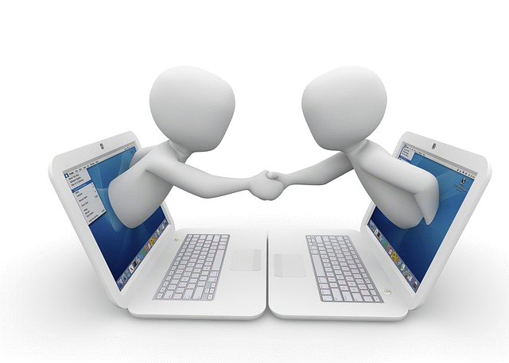

- During each single interaction between researcher and respondent, done through new research tool, **both sides** should receive something **valuable** for them.
- In consequence, people are **intrinsically motivated** to become respondents **repeatedly**, **for a long time**.

## What can be valuable for respondents?

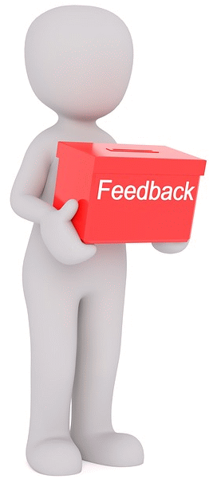

**Instant feedback**

- Respondents should be able to access feedback **relevant to their answers**.
- The feedback should be **provided immediately** at the end of a question set if not right after each answered question.
- The value of the feedback will be much higher for a respondent, if the feedback will be **highly customized** to this particular respondent.
  - The simplistic but existing in real-world example of this approach is a **salary survey**, which asks you about your current salary and compares it to salaries of people similar to you.

## Sources of data-driven feedback

The feedback for a given respondent can be based on different data sources:

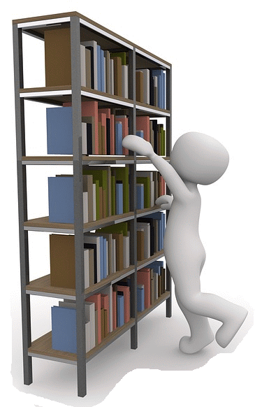

- the **answer** of the respondent  
  to the given question,
- **previous answers** of the respondent  
  to the given question,
- answers of the respondent  
  to **other questions**,
- answers of **other respondents**  
  to given or other questions,
- external **open data**  
  (research or administrative) ,
- outcomes from **reference studies**  
  (aggregated or summarized),
- other sources.

## The role of Data Science in the new model

**The role of Data Science is** to use multiple data sources, statistical inference, machine learning algorithms, and interactive data visualization, among others, **to provide feedback** to the respondents, which is

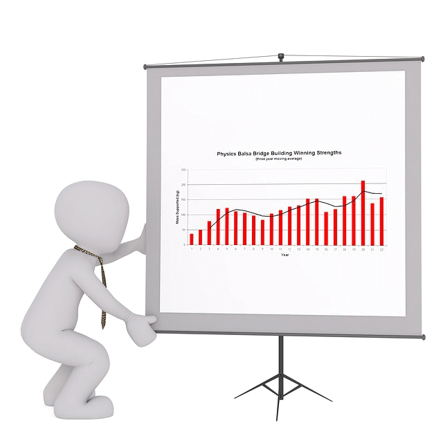

easily understandable,  
highly customized,  
visually atractive,  
comprehensive,  
truly valuable,  
data-driven,  
instant.

## Possible applications

- **evaluating services** provided by private companies or governmental agencies,
- **educating** respondents about the facts and **counteract spreading misleading information**.

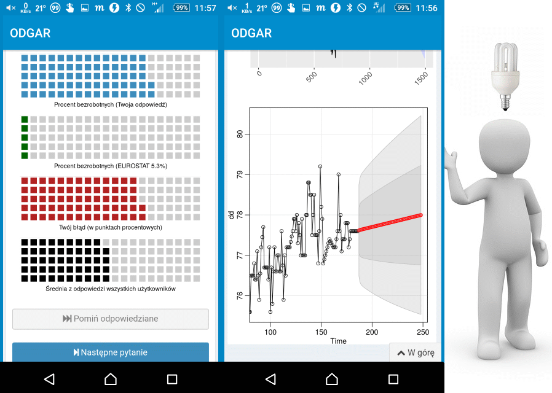

- **tracking opinions** within local communities,
- **monitoring** customer satisfaction,
- **evaluating public policies**,
- **assessing** performance of local authorities,
- **rating** educational and cultural institutions,
- **making forecasts** about social and political events,
- **tracking trends** and changes in attitudes,
- helping respondents **fighting with bad habbits**,

## Call for Collaboration!

Let's **develop** this new model further!  
Let's **implement** it into new research tools!  
Let's **test** it on different use cases!  
Let's **share** the results!

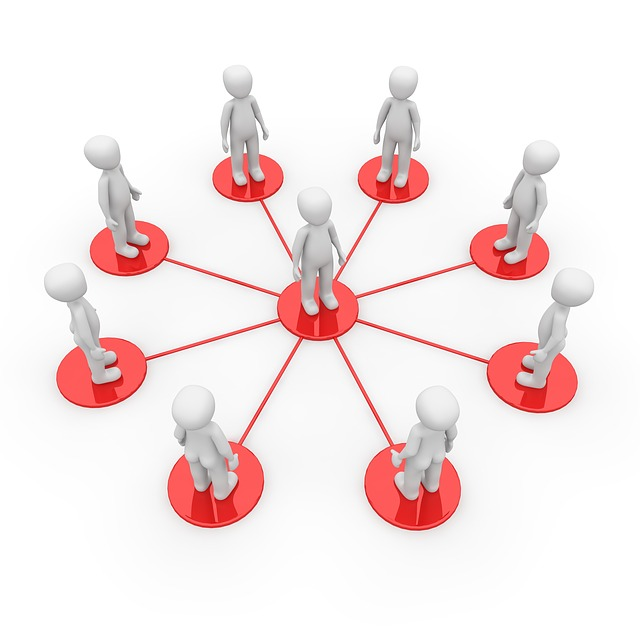

Join the persuit for **better research techniques and tools** for declarative data collection to **enable more Data Science for Social Good!**

## Thank you!

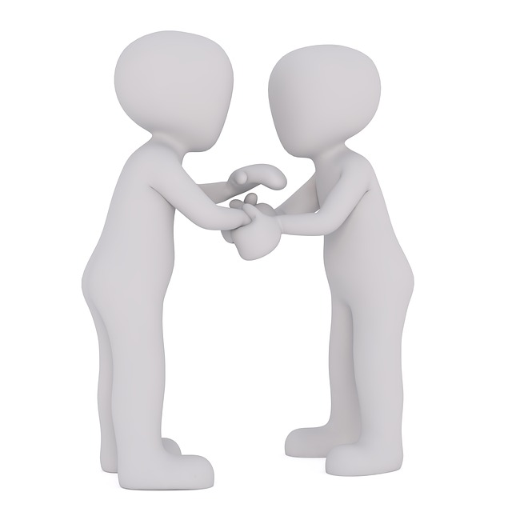